# AFFIP_session_data

Nico Bast

2025-12-03

# 1 A-FFIP session data

Fragestellung - spezifische Hypothesen ausstehend: Cluster der Therapieziele identifizieren - Verlauf der Probanden

1. Bildet sich der theoretische Ansatz des A-FFIP-Manuals mit den einzelne Förderbereichen sowie den Übungen von leicht bis Experte auch in der praktischen Arbeit mit den einzelnen Kindern ab? D.h. lernen die Kinder wie angenommen durch die Therapie aufeinander aufbauend über die entsprechenden Übungen?
2. Mit welchen Förderbereichen wird begonnen? Gibt es hier Zusammenhänge mit Alter, nonverbaler und verbaler Entwicklung sowie autistischer Kernsymptomatik und anderen Verhaltensweisen?
3. Wie bauen die Förderbereiche aufeinander auf, von welchem Förderbereich wird zum anderen gewechselt? Gibt es hier spezifische Muster, sind diese vergleichbar zwischen den Kindern oder zeigen verschiedene Gruppen von Kindern in sich ähnliche aber zwischen den Gruppen unterschiedliche Muster? Gibt es hier Zusammenhänge mit Alter, nonverbaler und verbaler Entwicklung sowie autistischer Kernsymptomatik und anderen Verhaltensweisen?

```r
#session data --> multiple rows per participant per session
project_folder<-"C:/Users/nico/Nextcloud/data_AFFIP/rct_data"
session_path<-paste0(project_folder,'/export_session_20230728.csv')
df_session<-read.csv(session_path)

#therapy data --> one row per participant per session
therapy_path<-paste0(project_folder,'/export_therapy_20230728.csv') #therapy session info - per session
df_therapy<-read.csv(therapy_path)
```

## 1.1 variable description

```r
#Bezugsperson anwesen
table(df_therapy$thcg) %>%
  kbl(caption = "Bezugsperson anwesend (0 = no, 1=yes)") %>%
  kable_classic(full_width = T, html_font = "Cambria")
```

Bezugsperson anwesend (0 = no, 1=yes)

| Var1 | Freq |
| --- | --- |
| 0 | 3034 |
| 1 | 1556 |

```r
# --> inclusion only with 0

#Schwerpunkt
table(df_therapy$focus) %>%
  kbl(caption = "Bezugsperson anwesend (1 = Elternarbeit, 2 = Kind, 3 = Austausch / Umfeld)") %>%
  kable_classic(full_width = T, html_font = "Cambria")
```

| Var1 | Freq |
| --- | --- |
| 1 | 277 |
| 2 | 4207 |
| 3 | 106 |

```r
# 1 = Elternarbeit
# 2 = Kind
# 3 = Austausch / Umfeld


#Setting
table(df_therapy$set) %>%
  kbl(caption = "Setting (1 = Einzel, 2 = Gruppe, 3 = Gespräch, 4 = Hospitation Kindergarten") %>%
  kable_classic(full_width = T, html_font = "Cambria")
```

Setting (1 = Einzel, 2 = Gruppe, 3 = Gespräch, 4 = Hospitation Kindergarten

| Var1 | Freq |
| --- | --- |
| 1 | 4118 |
| 2 | 77 |
| 3 | 351 |
| 4 | 44 |

```r
# 1 = Einzel
# 2 = Gruppe
# 3 = Gespräch
# 4 = Hospitation Kindergarten

print('data should be limited to: ohne Bezugsperson (0), Kindzentriert (2), Einzeltherapie (1) )')
```

```
## [1] "data should be limited to: ohne Bezugsperson (0), Kindzentriert (2), Einzeltherapie (1) )"
```

```r
table(df_therapy$thcg,df_therapy$focus,df_therapy$set) %>%
  kbl(caption = "Bezugsperson x Schwerpunkt x Setting",
      col.names = c('Bezugsperson','Schwerpunkt','Setting','N')) %>%
  kable_classic(full_width = T, html_font = "Cambria")
```

Bezugsperson x Schwerpunkt x Setting

| Bezugsperson | Schwerpunkt | Setting | N |
| --- | --- | --- | --- |
| 0 | 1 | 1 | 0 |
| 1 | 1 | 1 | 5 |
| 0 | 2 | 1 | 2919 |
| 1 | 2 | 1 | 1194 |
| 0 | 3 | 1 | 0 |
| 1 | 3 | 1 | 0 |
| 0 | 1 | 2 | 1 |
| 1 | 1 | 2 | 0 |
| 0 | 2 | 2 | 70 |
| 1 | 2 | 2 | 6 |
| 0 | 3 | 2 | 0 |
| 1 | 3 | 2 | 0 |
| 0 | 1 | 3 | 1 |
| 1 | 1 | 3 | 270 |
| 0 | 2 | 3 | 3 |
| 1 | 2 | 3 | 15 |
| 0 | 3 | 3 | 21 |
| 1 | 3 | 3 | 41 |
| 0 | 1 | 4 | 0 |
| 1 | 1 | 4 | 0 |
| 0 | 2 | 4 | 0 |
| 1 | 2 | 4 | 0 |
| 0 | 3 | 4 | 19 |
| 1 | 3 | 4 | 25 |

```r
#Diagnostiktermin
table(df_therapy$diag) %>%
  kbl(caption = "Diagnostiktermin (0 = nein)") %>%
  kable_classic(full_width = T, html_font = "Cambria")
```

Diagnostiktermin (0 = nein)

| Var1 | Freq |
| --- | --- |
| 0 | 4490 |
| 1 | 1 |
| 3 | 64 |
| 4 | 62 |
| 5 | 62 |
| 6 | 52 |

```r
# 0 = kein Diagnostiktermin

print('discussion point: Hat die Position des Zieles eines Bedeutung (1 = wichtigstes Ziel?)')
```

```
## [1] "discussion point: Hat die Position des Zieles eines Bedeutung (1 = wichtigstes Ziel?)"
```

```r
#Ziel Nummer
table(df_session$aim)  %>%
  kbl(caption = "Mindestanzhal von Zielen pro Sitzung (kummulativ)") %>%
  kable_classic(full_width = T, html_font = "Cambria")
```

Mindestanzhal von Zielen pro Sitzung (kummulativ)

| Var1 | Freq |
| --- | --- |
| 0 | 1 |
| 1 | 4161 |
| 2 | 4154 |
| 3 | 4117 |
| 4 | 3992 |
| 5 | 3823 |
| 6 | 3586 |
| 7 | 2618 |
| 8 | 1112 |
| 9 | 15 |

```r
##-->  aim number within the session (3 = third of three aims)

# table(df_session$aimno) %>%
#   kbl(caption = "Anzahl von Zielen pro Sitzung (kummulativ)") %>%
#   kable_classic(full_width = T, html_font = "Cambria")
# #--> übergeordnete Ziele anschauen: 9.2 oder 10.6.1 - ersten zwei Nummern aus Liste
# - bei 10ern sind drei Nummern relevant
# - bei 9 er
# A1-A4 rausfiltern - da zu Beginn --> das erste Mal, wo an Ziele gearbeitet wird
#

print('discussion point: Sind diese Variablen relevant?')
```

```
## [1] "discussion point: Sind diese Variablen relevant?"
```

```r
#Übung durchgeführt
table(df_session$practex)
```

```
##
##     0     1
##  3809 23770
```

```r
#if, then: Übung variiert
table(df_session$practvar)
```

```
##
##     0     1     2
##  7878 14232     2
```

```r
#Ausmaß Hilfestellung: 0 = ohne Hilfe, 1 = mit Hilfestellung, 2 = selbstständig
table(df_session$help)
```

```
##
##     0     1     2     8
##  2643 13932  5535     1
```

```r
#Zielebene gemeistert - 0= nein, 1 = teilweise, 2 = vollständig
table(df_session$achieve)
```

```
##
##     0     1     2     8
##  2477 14363  5270     1
```

```r
#herausfordernde Verhaltensweisen gezeigt
table(df_session$behave)
```

```
##
##     0     1     2     7
## 25842  1706     4    27
```

## 1.2 merge data

- merges df_session (session data, p.12ff) and df_therapy (therapy data, p1-12)
- df_session: row per aim per session (n=27579)
- df_therapy: row per session (n=4731)

```r
df_trial<-merge(df_session, df_therapy,
            by.x = c("centno", "scrnno", "sessno"),
            by.y= c("centno", "scrnno", "thsessno"))

names(df_trial)
```

```
##  [1] "centno"        "scrnno"        "sessno"        "bdate_m.x"
##  [5] "bdate_y.x"     "sdate_d"       "sdate_m"       "sdate_y"
##  [9] "therapeut"     "therapeutno"   "cotherapeut"   "cotherapeutno"
## [13] "sesscg"        "sesscg1"       "sesscg2"       "sesscg3"
## [17] "sesscg4"       "sesscg5"       "sesscg6"       "sesscg7"
## [21] "sesscg8"       "sessothcg"     "aim"           "aimno"
## [25] "practex"       "practvar"      "help"          "achieve"
## [29] "behave"        "sdate_"        "bdate_m.y"     "bdate_y.y"
## [33] "week"          "thdate_d"      "thdate_m"      "thdate_y"
## [37] "thcg"          "thcg1"         "thcg2"         "thcg3"
## [41] "thcg4"         "focus"         "set"           "diag"
## [45] "patcsdoc"      "sessdoc"       "thidate_d"     "thidate_m"
## [49] "thidate_y"     "thinvest"      "thisign"       "thpage"
## [53] "thdate_"       "thidate"
```

## 1.3 sample definition

- retain only data for subsequent analysis that is
  - without caregiver (df_therapy$thcg==0)
  - focused on child (df_therapy$focus==2)
  - Einzeltherapie (df_therapy$set==1)

```r
total_aims<-nrow(df_trial)

df_trial<-df_trial[df_therapy$thcg==0 & df_therapy$focus==2 & df_therapy$set==1,]


print(paste0('retained data percentage:',round(nrow(df_trial)/total_aims,2)))
```

```
## [1] "retained data percentage:0.65"
```

## 1.4 number of participants

```r
#participants
print('number of participants:')
```

```
## [1] "number of participants:"
```

```r
length(table(interaction(df_trial$centno,df_trial$scrnno,drop=T)))
```

```
## [1] 66
```

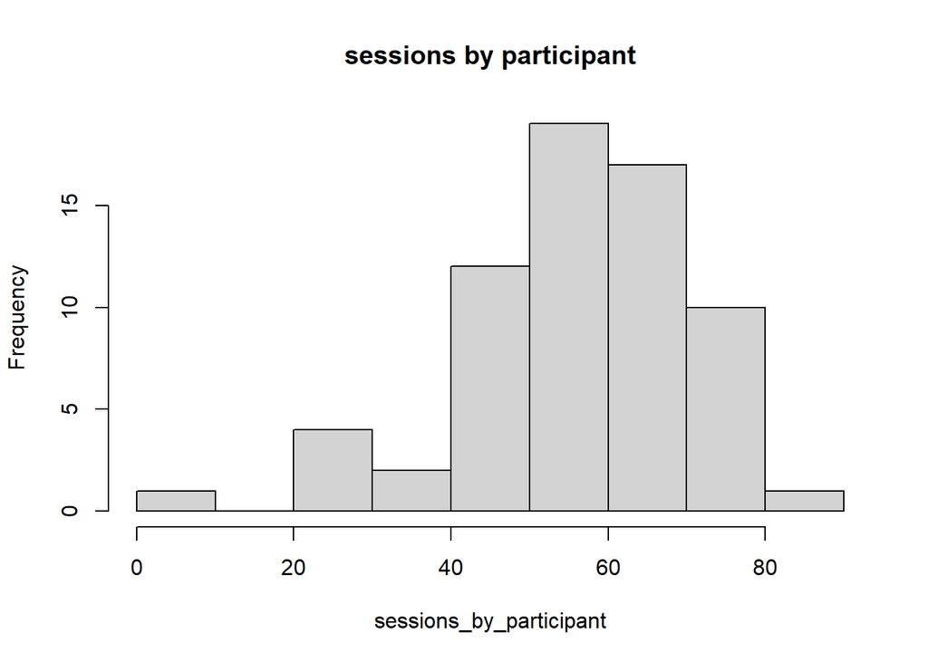

```r
#session by participant
sessions_by_participant<-as.numeric(
  by(df_trial$sessno,interaction(df_trial$centno,df_trial$scrnno,drop=T),function(x){length(unique(x))}))
hist(sessions_by_participant,main = 'sessions by participant')
```

```r
print('participant IDs')
```

```
## [1] "participant IDs"
```

```r
names(table(interaction(df_trial$centno,df_trial$scrnno,drop=T)))
```

```
##  [1] "4.1"   "2.2"   "3.2"   "4.2"   "1.3"   "2.4"   "3.4"   "1.5"   "4.9"
## [10] "4.10"  "1.11"  "2.11"  "4.14"  "4.15"  "2.16"  "1.17"  "4.17"  "2.19"
## [19] "4.19"  "2.21"  "4.22"  "4.23"  "4.25"  "2.29"  "1.31"  "2.31"  "3.31"
## [28] "1.32"  "2.33"  "1.34"  "2.35"  "1.37"  "2.39"  "1.42"  "2.46"  "1.48"
## [37] "1.50"  "1.51"  "2.51"  "2.52"  "1.53"  "1.54"  "2.54"  "1.55"  "3.55"
## [46] "1.60"  "1.62"  "1.70"  "1.74"  "1.76"  "1.78"  "1.81"  "1.82"  "1.83"
## [55] "1.87"  "1.93"  "1.94"  "1.97"  "3.98"  "1.99"  "1.101" "1.105" "3.106"
## [64] "1.113" "1.116" "1.117"
```

## 1.5 therapy aims

- can be more than one per session
- encoded by “aimno” variable (e.g. 10.6.2.1)
  - first or two numbers define devleopmental area (e.g. 9, 10.2-10.6)
  - first three numbers define specific aim (e.g. 10.6.2)
  - last number defines expert level (1,2,3)

### 1.5.1 developmental area

- Entwicklungsbereiche (9.2 - 10.6)

```r
## Ziele overall
#table(df_trial$aimno)

dev_area<-substr(df_trial$aimno,1,8)
dev_area<-ifelse(nchar(dev_area)==5,substr(dev_area,1,1),dev_area)
dev_area<-ifelse(nchar(dev_area)==8,substr(dev_area,1,4),dev_area)
dev_area<-ifelse(grepl("A",dev_area),'A',dev_area)
dev_area<-ifelse(grepl("B",dev_area),'B',dev_area)
dev_area<-ifelse(grepl("-8",dev_area),NA,dev_area)

dev_area_char<-dev_area
dev_area<-as.factor(dev_area)
levels(dev_area)<-c('communication & speech','interaction & play','emotion','cognitive ability','daily living skills','basic abilities','introduction','reduction of unwanted behaviors')

df_trial$dev_area<-dev_area
df_trial$dev_area_char<-dev_area_char

dev_area_table<-data.frame(sort(table(df_trial$dev_area),decreasing = TRUE))
dev_area_table_char<-data.frame(sort(table(df_trial$dev_area_char),decreasing = TRUE))
dev_area_table$dev_area_char<-dev_area_table_char$Var1
dev_area_table<-dev_area_table[,c(1,3,2)]

dev_area_table %>%
  kbl(caption = "developmental areas across sessions") %>%
  kable_classic(full_width = T, html_font = "Cambria")
```

developmental areas across sessions

| Var1 | dev_area_char | Freq |
| --- | --- | --- |
| basic abilities | 9 | 5570 |
| communication & speech | 10.2 | 4996 |
| interaction & play | 10.3 | 2742 |
| introduction | A | 1223 |
| daily living skills | 10.6 | 1166 |
| cognitive ability | 10.5 | 966 |
| emotion | 10.4 | 475 |
| reduction of unwanted behaviors | B | 67 |

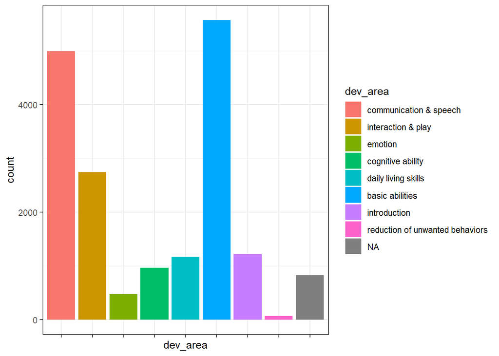

```r
ggplot(df_trial,aes(x=dev_area,fill=dev_area))+geom_bar()+theme(axis.text.x=element_blank())
```

### 1.5.2 therapy aims - across sessions

- an welchen zielen wurde gearbeitet?

```r
## Ziele overall
#table(df_trial$aimno)

aims<-substr(df_trial$aimno,1,8)
aims<-ifelse(nchar(aims)==8,substr(aims,1,6),aims)
aims<-ifelse(nchar(aims)==5,substr(aims,1,3),aims)
aims<-ifelse(grepl("-8",aims),NA,aims)

aims_rank<-aims
aims_rank<-ifelse(grepl('10',aims_rank),substr(aims_rank,6,6),aims_rank)
aims_rank<-ifelse(grepl('9',aims_rank),substr(aims_rank,3,3),aims_rank)
aims_rank<-ifelse(grepl('A',aims_rank),NA,aims_rank)
aims_rank<-ifelse(grepl('B',aims_rank),NA,aims_rank)
df_trial$aims_rank<-aims_rank

aims_char<-aims
aims<-as.factor(aims)
levels(aims)<-c('eye contact','passive vocabulary','gesture','expressive language (supported)',
                'expressive language extended','questions & answers','making contact',

                'shared attention','exchange','sharing','non-interactive play','simple shared play',
                'rule-based play','symbolic play','role play',

                'emotion recognition','emotion expression','emotion regulation',

                'classification','characteristics/opposites','memory',
                'drawing','quantitative understanding','theory of mind',
                'common knowledge',

                'daily routines','toilet training',
                'problem solving','awareness of danger','spatial awareness','temporal orientation',

                'attention control','gaze following',
                'imitation','representation','action planing','self awareness',

                'testing reinforcement','building therapeutic alliance','situational control','separation from caregiver',

                'aggression','stereotypic behavior','alternatives','anxiety','avoidance'

                )

df_trial$aims<-aims
df_trial$aims_char<-aims_char

aims_table<-data.frame(sort(table(df_trial$aims),decreasing = TRUE))
aims_table_char<-data.frame(sort(table(df_trial$aims_char),decreasing = TRUE))
aims_table$aims_char<-aims_table_char$Var1
aims_table<-aims_table[,c(1,3,2)]

  aims_table %>%
  kbl(caption = "occurance of aims across sessions") %>%
  kable_classic(full_width = F, html_font = "Cambria")
```

occurance of aims across sessions

| Var1 | aims_char | Freq |
| --- | --- | --- |
| eye contact | 10.2.1 | 2013 |
| imitation | 9.4 | 1392 |
| attention control | 9.2 | 1242 |
| expressive language extended | 10.2.5 | 1133 |
| action planing | 9.6 | 992 |
| gaze following | 9.3 | 954 |
| passive vocabulary | 10.2.2 | 852 |
| problem solving | 10.6.3 | 714 |
| self awareness | 9.7 | 643 |
| expressive language (supported) | 10.2.4 | 638 |
| shared attention | 10.3.1 | 624 |
| classification | 10.5.1 | 527 |
| rule-based play | 10.3.6 | 515 |
| simple shared play | 10.3.5 | 495 |
| situational control | A3 | 447 |
| exchange | 10.3.2 | 373 |
| representation | 9.5 | 347 |
| emotion recognition | 10.4.1 | 314 |
| building therapeutic alliance | A2 | 283 |
| testing reinforcement | A1 | 270 |
| non-interactive play | 10.3.4 | 255 |
| separation from caregiver | A4 | 223 |
| temporal orientation | 10.6.6 | 192 |
| sharing | 10.3.3 | 185 |
| daily routines | 10.6.1 | 168 |
| symbolic play | 10.3.7 | 156 |
| making contact | 10.2.7 | 139 |
| role play | 10.3.8 | 139 |
| questions & answers | 10.2.6 | 137 |
| quantitative understanding | 10.5.5 | 132 |
| theory of mind | 10.5.6 | 120 |
| emotion regulation | 10.4.3 | 104 |
| gesture | 10.2.3 | 84 |
| drawing | 10.5.4 | 77 |
| characteristics/opposites | 10.5.2 | 73 |
| emotion expression | 10.4.2 | 57 |
| awareness of danger | 10.6.4 | 56 |
| anxiety | B6 | 31 |
| common knowledge | 10.5.7 | 26 |
| toilet training | 10.6.2 | 26 |
| alternatives | B5 | 19 |
| avoidance | B8 | 13 |
| memory | 10.5.3 | 11 |
| spatial awareness | 10.6.5 | 10 |
| aggression | B1 | 3 |
| stereotypic behavior | B3 | 1 |

```r
aims_table_byrank<-as.matrix(table(df_trial$dev_area,df_trial$aims_rank))

  aims_table_byrank %>%
  kbl(caption = "aim ranks by developmental area across sessions") %>%
  kable_classic(full_width = F, html_font = "Cambria")
```

aim ranks by developmental area across sessions

|  | 1 | 2 | 3 | 4 | 5 | 6 | 7 | 8 |
| --- | --- | --- | --- | --- | --- | --- | --- | --- |
| communication & speech | 2013 | 852 | 84 | 638 | 1133 | 137 | 139 | 0 |
| interaction & play | 624 | 373 | 185 | 255 | 495 | 515 | 156 | 139 |
| emotion | 314 | 57 | 104 | 0 | 0 | 0 | 0 | 0 |
| cognitive ability | 527 | 73 | 11 | 77 | 132 | 120 | 26 | 0 |
| daily living skills | 168 | 26 | 714 | 56 | 10 | 192 | 0 | 0 |
| basic abilities | 0 | 1242 | 954 | 1392 | 347 | 992 | 643 | 0 |
| introduction | 0 | 0 | 0 | 0 | 0 | 0 | 0 | 0 |
| reduction of unwanted behaviors | 0 | 0 | 0 | 0 | 0 | 0 | 0 | 0 |

### 1.5.3 therapy aims - at first session

```r
#create data
df_firstaims<-df_trial[df_trial$dev_area!='introduction',]
df_firstaims<-split(df_firstaims,interaction(df_firstaims$centno,df_firstaims$scrnno,drop=T))
df_firstaims<-lapply(df_firstaims,function(x){
  earliest_session<-min(x$sessno)
  x<-x[x$sessno==earliest_session,]
  return(x)
})
df_firstaims<-rbindlist(df_firstaims)
```

#### 1.5.3.1 number of sessions till first session with aims

- Berechnung der Anzahl der Therapiesitzung und Tage, die Kind gebraucht hat, bis an Therapiezielen überhaupt gearbeitet werden kann (Kriterium: Anzahl der „A“-Sitzungen zu Beginn der Therapie“ sowie die Zeitspanne dieser Sitzungen).

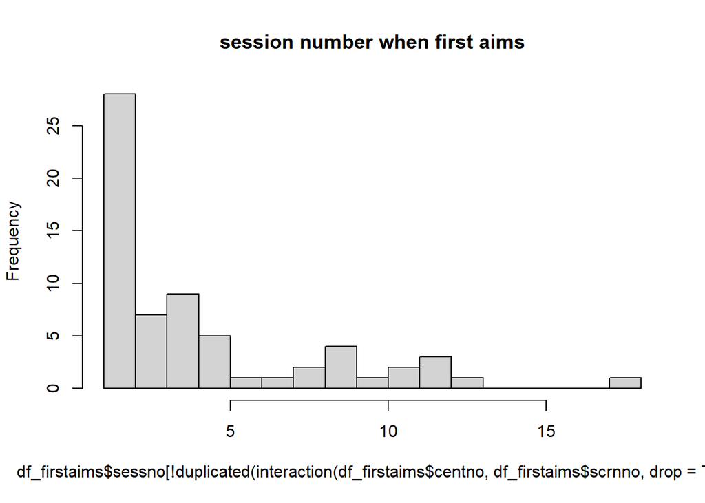

```r
#session number after introduction
hist(df_firstaims$sessno[!duplicated(interaction(df_firstaims$centno,df_firstaims$scrnno,drop=T))],
     main = 'session number when first aims',20)
```

```r
table(df_firstaims$sessno[!duplicated(interaction(df_firstaims$centno,df_firstaims$scrnno,drop=T))]) %>%
  kbl(caption = "Session number after introduction (after 'A')") %>%
  kable_classic(full_width = T, html_font = "Cambria")
```

Session number after introduction (after ‘A’)

| Var1 | Freq |
| --- | --- |
| 1 | 11 |
| 2 | 17 |
| 3 | 7 |
| 4 | 9 |
| 5 | 5 |
| 6 | 1 |
| 7 | 1 |
| 8 | 2 |
| 9 | 4 |
| 10 | 1 |
| 11 | 2 |
| 12 | 3 |
| 13 | 1 |
| 18 | 1 |

#### 1.5.3.2 time till first session with aims

```r
#extract date of first session
df_firstsession<-df_therapy[df_therapy$thsessno==1,]
df_firstsession<-df_firstsession[,names(df_firstsession) %in% c('centno','scrnno','thdate_')]
names(df_firstsession)<-c('centno','scrnno','date_first_session')

#add
df_firstaims<-merge(df_firstaims,df_firstsession,by =c("centno", "scrnno"))

# table(df_firstaims$sdate_)
# table(df_firstaims$date_first_session)

#convert to date
df_firstaims$sdate_<- as.Date(df_firstaims$sdate_, format = "%d/%m/%y")
df_firstaims$date_first_session<- as.Date(df_firstaims$date_first_session, format = "%d/%m/%y")

#select only one row per participant
df_firstaims_uniqueID<-df_firstaims[!duplicated(interaction(df_firstaims$centno,df_firstaims$scrnno,drop=T)),]

time_to_first_session<-data.frame(df_firstaims_uniqueID$sdate_-df_firstaims_uniqueID$date_first_session)
names(time_to_first_session)<-'time_in_d'

table(time_to_first_session) %>%
   kbl(caption = "time in days from introduction to session with first aims") %>%
  kable_classic(full_width = T, html_font = "Cambria")
```

time in days from introduction to session with first aims

| time_in_d | Freq |
| --- | --- |
| 0 | 11 |
| 1 | 1 |
| 2 | 4 |
| 3 | 1 |
| 4 | 1 |
| 5 | 1 |
| 6 | 1 |
| 7 | 9 |
| 9 | 1 |
| 10 | 3 |
| 11 | 1 |
| 12 | 1 |
| 13 | 2 |
| 14 | 6 |
| 15 | 2 |
| 16 | 1 |
| 19 | 1 |
| 22 | 1 |
| 28 | 2 |
| 32 | 1 |
| 33 | 3 |
| 35 | 1 |
| 42 | 2 |
| 45 | 1 |
| 48 | 1 |
| 56 | 2 |
| 57 | 1 |
| 63 | 1 |
| 66 | 1 |
| 98 | 1 |

```
## Defaulting to continuous.
```

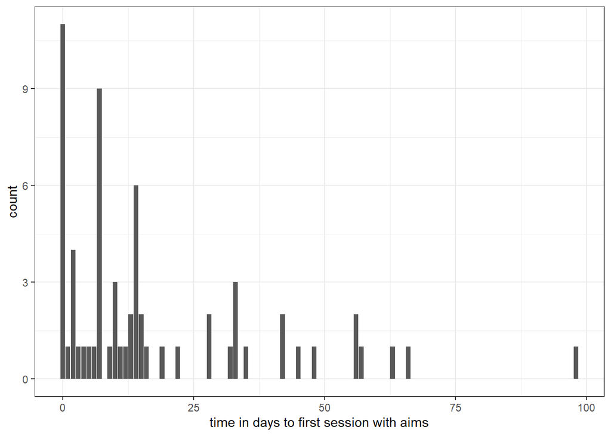

```r
ggplot(time_to_first_session,aes(x=time_in_d))+geom_bar()+xlab('time in days to first session with aims')
```

```r
#crosscheck - plausible that n=10 have no introduction
#with(df_trial[df_trial$aim==1,],by(dev_area,interaction(centno,scrnno,drop=T),table))
```

#### 1.5.3.3 aims in first session

the number of aims can be more than one per child

```r
#table overview
aims_table<-sort(table(droplevels(df_firstaims$aims)),decreasing = TRUE)

  aims_table %>%
  kbl(caption = "aims in the first session after introdcution") %>%
  kable_classic(full_width = F, html_font = "Cambria")
```

aims in the first session after introdcution

| Var1 | Freq |
| --- | --- |
| eye contact | 34 |
| gaze following | 26 |
| attention control | 25 |
| imitation | 15 |
| action planing | 15 |
| representation | 10 |
| passive vocabulary | 9 |
| expressive language extended | 7 |
| problem solving | 6 |
| self awareness | 6 |
| non-interactive play | 3 |
| simple shared play | 3 |
| expressive language (supported) | 2 |
| making contact | 2 |
| shared attention | 2 |
| exchange | 2 |
| classification | 2 |
| daily routines | 2 |
| rule-based play | 1 |
| drawing | 1 |
| quantitative understanding | 1 |
| temporal orientation | 1 |
| stereotypic behavior | 1 |

```r
#aims by participant
table_aimspart<-by(df_firstaims$aims,interaction(df_firstaims$centno,df_firstaims$scrnno,drop=T),function(x){table(droplevels(x))})

table_aimspart<-sapply(table_aimspart,dimnames)
max_length<-max(sapply(table_aimspart,length))
table_aimspart<-lapply(table_aimspart,function(x){
  current_length<-length(x)
  new_vector<-rep(NA,max_length)
  new_vector[1:current_length]<-x
  return(new_vector)})

table_aimspart<-rbind.data.frame(table_aimspart)

table_aimspart<-data.frame(t(table_aimspart))
names(table_aimspart)<-paste('goal',1:length(names(table_aimspart)))
row.names(table_aimspart)<-substr(row.names(table_aimspart),2,nchar(row.names(table_aimspart)))

print('discussion point: Factor in the number of aims per participant?')
```

```
## [1] "discussion point: Factor in the number of aims per participant?"
```

```r
table_aimspart[order(table_aimspart[,1]),] %>%
  kbl(caption = "aims in the first session after introdcution by participant") %>%
  kable_classic(full_width = F, html_font = "Cambria")
```

aims in the first session after introdcution by participant

|  | goal 1 | goal 2 | goal 3 | goal 4 | goal 5 | goal 6 | goal 7 |
| --- | --- | --- | --- | --- | --- | --- | --- |
| 4.2 | action planing | NA | NA | NA | NA | NA | NA |
| 4.15 | attention control | gaze following | representation | NA | NA | NA | NA |
| 2.19 | attention control | gaze following | representation | NA | NA | NA | NA |
| 2.29 | attention control | representation | NA | NA | NA | NA | NA |
| 2.31 | attention control | imitation | representation | self awareness | NA | NA | NA |
| 1.34 | attention control | NA | NA | NA | NA | NA | NA |
| 2.39 | attention control | gaze following | representation | NA | NA | NA | NA |
| 1.51 | attention control | imitation | action planing | NA | NA | NA | NA |
| 1.54 | attention control | imitation | NA | NA | NA | NA | NA |
| 1.74 | attention control | gaze following | NA | NA | NA | NA | NA |
| 1.113 | attention control | gaze following | NA | NA | NA | NA | NA |
| 2.4 | classification | attention control | gaze following | representation | NA | NA | NA |
| 2.16 | expressive language (supported) | NA | NA | NA | NA | NA | NA |
| 1.82 | expressive language (supported) | NA | NA | NA | NA | NA | NA |
| 1.3 | expressive language extended | attention control | NA | NA | NA | NA | NA |
| 1.97 | expressive language extended | NA | NA | NA | NA | NA | NA |
| 2.2 | eye contact | drawing | daily routines | gaze following | representation | self awareness | NA |
| 4.9 | eye contact | NA | NA | NA | NA | NA | NA |
| 4.10 | eye contact | attention control | NA | NA | NA | NA | NA |
| 1.11 | eye contact | gaze following | imitation | NA | NA | NA | NA |
| 2.11 | eye contact | non-interactive play | gaze following | representation | NA | NA | NA |
| 4.14 | eye contact | NA | NA | NA | NA | NA | NA |
| 4.17 | eye contact | expressive language extended | non-interactive play | attention control | NA | NA | NA |
| 4.19 | eye contact | simple shared play | attention control | NA | NA | NA | NA |
| 2.21 | eye contact | attention control | gaze following | NA | NA | NA | NA |
| 4.22 | eye contact | attention control | NA | NA | NA | NA | NA |
| 4.23 | eye contact | attention control | imitation | NA | NA | NA | NA |
| 4.25 | eye contact | NA | NA | NA | NA | NA | NA |
| 1.32 | eye contact | action planing | NA | NA | NA | NA | NA |
| 2.33 | eye contact | quantitative understanding | gaze following | action planing | self awareness | NA | NA |
| 2.35 | eye contact | passive vocabulary | classification | gaze following | imitation | action planing | NA |
| 1.37 | eye contact | shared attention | exchange | simple shared play | NA | NA | NA |
| 1.48 | eye contact | NA | NA | NA | NA | NA | NA |
| 1.50 | eye contact | passive vocabulary | gaze following | imitation | representation | action planing | NA |
| 2.52 | eye contact | action planing | NA | NA | NA | NA | NA |
| 2.54 | eye contact | attention control | NA | NA | NA | NA | NA |
| 1.55 | eye contact | problem solving | temporal orientation | NA | NA | NA | NA |
| 3.55 | eye contact | attention control | gaze following | imitation | NA | NA | NA |
| 1.60 | eye contact | expressive language extended | making contact | simple shared play | rule-based play | problem solving | NA |
| 1.62 | eye contact | expressive language extended | problem solving | action planing | NA | NA | NA |
| 1.70 | eye contact | passive vocabulary | expressive language extended | problem solving | action planing | NA | NA |
| 1.76 | eye contact | attention control | action planing | NA | NA | NA | NA |
| 1.83 | eye contact | passive vocabulary | shared attention | problem solving | imitation | representation | NA |
| 1.93 | eye contact | passive vocabulary | gaze following | imitation | NA | NA | NA |
| 1.94 | eye contact | NA | NA | NA | NA | NA | NA |
| 1.101 | eye contact | passive vocabulary | attention control | gaze following | imitation | action planing | self awareness |
| 1.105 | eye contact | action planing | NA | NA | NA | NA | NA |
| 3.106 | eye contact | attention control | gaze following | imitation | NA | NA | NA |
| 1.116 | eye contact | daily routines | action planing | NA | NA | NA | NA |
| 1.117 | eye contact | NA | NA | NA | NA | NA | NA |
| 3.4 | gaze following | NA | NA | NA | NA | NA | NA |
| 1.17 | gaze following | NA | NA | NA | NA | NA | NA |
| 2.46 | gaze following | NA | NA | NA | NA | NA | NA |
| 1.87 | gaze following | NA | NA | NA | NA | NA | NA |
| 1.42 | imitation | NA | NA | NA | NA | NA | NA |
| 2.51 | imitation | action planing | self awareness | NA | NA | NA | NA |
| 1.81 | imitation | action planing | NA | NA | NA | NA | NA |
| 3.31 | making contact | NA | NA | NA | NA | NA | NA |
| 3.98 | non-interactive play | attention control | gaze following | NA | NA | NA | NA |
| 3.2 | passive vocabulary | exchange | attention control | gaze following | NA | NA | NA |
| 1.5 | passive vocabulary | expressive language extended | NA | NA | NA | NA | NA |
| 1.31 | passive vocabulary | gaze following | NA | NA | NA | NA | NA |
| 1.78 | problem solving | NA | NA | NA | NA | NA | NA |
| 1.99 | self awareness | NA | NA | NA | NA | NA | NA |
| 4.1 | stereotypic behavior | NA | NA | NA | NA | NA | NA |

#### 1.5.3.4 clustering based on first aims

- Gower Distance hierarchical clustering
- considers missing data (not all participants have equal number of aims)
- categorical data type

```r
#translate
table_aimspart_factor<-lapply(table_aimspart,as.factor)
table_aimspart_factor<-data.frame(table_aimspart_factor[1],
                                  table_aimspart_factor[2],
                                  table_aimspart_factor[3],
                                  table_aimspart_factor[4],
                                  table_aimspart_factor[5],
                                  table_aimspart_factor[6],
                                  table_aimspart_factor[7])

rownames(table_aimspart_factor)<-row.names(table_aimspart)


# Compute Gower distance
gower_dist <- daisy(table_aimspart_factor, metric = "gower")
print('clustering metric - gower distance between pairwise comparisons (sum(1:64)):')
```

```
## [1] "clustering metric - gower distance between pairwise comparisons (sum(1:64)):"
```

```r
table(round(gower_dist,2))
```

```
##
##    0 0.17 0.25 0.33  0.4  0.5  0.6 0.67 0.75  0.8 0.83    1
##  240    1    4   23    1  204    4  131   59    8    6 1399
```

```r
# Perform hierarchical clustering
hc <- hclust(gower_dist, method = "ward.D2")

# Cut into clusters (e.g., 3 clusters)
number_of_clusters<-5
print(paste('assumed number of clusters:',number_of_clusters))
```

```
## [1] "assumed number of clusters: 5"
```

```r
clusters <- cutree(hc, k = number_of_clusters)

# Add cluster labels to your data
table_aimspart_factor$start_cluster <- clusters

print('discussion point: language is difficult to consider as split across aims')
```

```
## [1] "discussion point: language is difficult to consider as split across aims"
```

```r
table_aimspart_factor[order(table_aimspart_factor[,8]),] %>%
  kbl(caption = "aims in the first session and starting CLUSTERS after introduction by participant") %>%
  kable_classic(full_width = F, html_font = "Cambria")
```

aims in the first session and starting CLUSTERS after introduction by participant

|  | goal.1 | goal.2 | goal.3 | goal.4 | goal.5 | goal.6 | goal.7 | start_cluster |
| --- | --- | --- | --- | --- | --- | --- | --- | --- |
| 4.1 | stereotypic behavior | NA | NA | NA | NA | NA | NA | 1 |
| 3.2 | passive vocabulary | exchange | attention control | gaze following | NA | NA | NA | 1 |
| 4.2 | action planing | NA | NA | NA | NA | NA | NA | 1 |
| 1.3 | expressive language extended | attention control | NA | NA | NA | NA | NA | 1 |
| 1.5 | passive vocabulary | expressive language extended | NA | NA | NA | NA | NA | 1 |
| 2.16 | expressive language (supported) | NA | NA | NA | NA | NA | NA | 1 |
| 1.31 | passive vocabulary | gaze following | NA | NA | NA | NA | NA | 1 |
| 3.31 | making contact | NA | NA | NA | NA | NA | NA | 1 |
| 1.42 | imitation | NA | NA | NA | NA | NA | NA | 1 |
| 2.51 | imitation | action planing | self awareness | NA | NA | NA | NA | 1 |
| 1.78 | problem solving | NA | NA | NA | NA | NA | NA | 1 |
| 1.81 | imitation | action planing | NA | NA | NA | NA | NA | 1 |
| 1.82 | expressive language (supported) | NA | NA | NA | NA | NA | NA | 1 |
| 1.97 | expressive language extended | NA | NA | NA | NA | NA | NA | 1 |
| 1.99 | self awareness | NA | NA | NA | NA | NA | NA | 1 |
| 2.2 | eye contact | drawing | daily routines | gaze following | representation | self awareness | NA | 2 |
| 4.9 | eye contact | NA | NA | NA | NA | NA | NA | 2 |
| 1.11 | eye contact | gaze following | imitation | NA | NA | NA | NA | 2 |
| 2.11 | eye contact | non-interactive play | gaze following | representation | NA | NA | NA | 2 |
| 4.14 | eye contact | NA | NA | NA | NA | NA | NA | 2 |
| 4.17 | eye contact | expressive language extended | non-interactive play | attention control | NA | NA | NA | 2 |
| 4.19 | eye contact | simple shared play | attention control | NA | NA | NA | NA | 2 |
| 4.25 | eye contact | NA | NA | NA | NA | NA | NA | 2 |
| 1.32 | eye contact | action planing | NA | NA | NA | NA | NA | 2 |
| 2.33 | eye contact | quantitative understanding | gaze following | action planing | self awareness | NA | NA | 2 |
| 2.35 | eye contact | passive vocabulary | classification | gaze following | imitation | action planing | NA | 2 |
| 1.37 | eye contact | shared attention | exchange | simple shared play | NA | NA | NA | 2 |
| 1.48 | eye contact | NA | NA | NA | NA | NA | NA | 2 |
| 1.50 | eye contact | passive vocabulary | gaze following | imitation | representation | action planing | NA | 2 |
| 2.52 | eye contact | action planing | NA | NA | NA | NA | NA | 2 |
| 1.55 | eye contact | problem solving | temporal orientation | NA | NA | NA | NA | 2 |
| 1.60 | eye contact | expressive language extended | making contact | simple shared play | rule-based play | problem solving | NA | 2 |
| 1.62 | eye contact | expressive language extended | problem solving | action planing | NA | NA | NA | 2 |
| 1.70 | eye contact | passive vocabulary | expressive language extended | problem solving | action planing | NA | NA | 2 |
| 1.83 | eye contact | passive vocabulary | shared attention | problem solving | imitation | representation | NA | 2 |
| 1.93 | eye contact | passive vocabulary | gaze following | imitation | NA | NA | NA | 2 |
| 1.94 | eye contact | NA | NA | NA | NA | NA | NA | 2 |
| 1.101 | eye contact | passive vocabulary | attention control | gaze following | imitation | action planing | self awareness | 2 |
| 1.105 | eye contact | action planing | NA | NA | NA | NA | NA | 2 |
| 1.116 | eye contact | daily routines | action planing | NA | NA | NA | NA | 2 |
| 1.117 | eye contact | NA | NA | NA | NA | NA | NA | 2 |
| 2.4 | classification | attention control | gaze following | representation | NA | NA | NA | 3 |
| 4.10 | eye contact | attention control | NA | NA | NA | NA | NA | 3 |
| 2.21 | eye contact | attention control | gaze following | NA | NA | NA | NA | 3 |
| 4.22 | eye contact | attention control | NA | NA | NA | NA | NA | 3 |
| 4.23 | eye contact | attention control | imitation | NA | NA | NA | NA | 3 |
| 2.54 | eye contact | attention control | NA | NA | NA | NA | NA | 3 |
| 3.55 | eye contact | attention control | gaze following | imitation | NA | NA | NA | 3 |
| 1.76 | eye contact | attention control | action planing | NA | NA | NA | NA | 3 |
| 3.98 | non-interactive play | attention control | gaze following | NA | NA | NA | NA | 3 |
| 3.106 | eye contact | attention control | gaze following | imitation | NA | NA | NA | 3 |
| 3.4 | gaze following | NA | NA | NA | NA | NA | NA | 4 |
| 1.17 | gaze following | NA | NA | NA | NA | NA | NA | 4 |
| 2.46 | gaze following | NA | NA | NA | NA | NA | NA | 4 |
| 1.87 | gaze following | NA | NA | NA | NA | NA | NA | 4 |
| 4.15 | attention control | gaze following | representation | NA | NA | NA | NA | 5 |
| 2.19 | attention control | gaze following | representation | NA | NA | NA | NA | 5 |
| 2.29 | attention control | representation | NA | NA | NA | NA | NA | 5 |
| 2.31 | attention control | imitation | representation | self awareness | NA | NA | NA | 5 |
| 1.34 | attention control | NA | NA | NA | NA | NA | NA | 5 |
| 2.39 | attention control | gaze following | representation | NA | NA | NA | NA | 5 |
| 1.51 | attention control | imitation | action planing | NA | NA | NA | NA | 5 |
| 1.54 | attention control | imitation | NA | NA | NA | NA | NA | 5 |
| 1.74 | attention control | gaze following | NA | NA | NA | NA | NA | 5 |
| 1.113 | attention control | gaze following | NA | NA | NA | NA | NA | 5 |

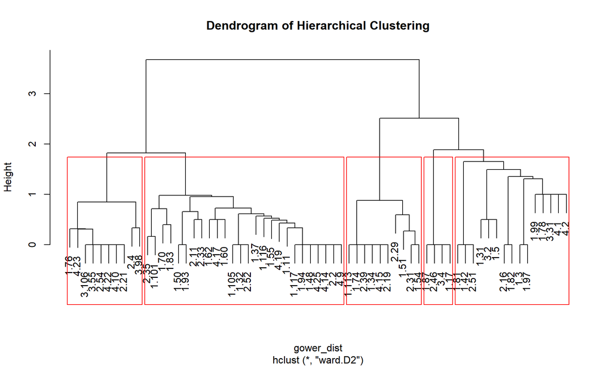

```r
# visualize cluster
plot(hc, labels = rownames(table_aimspart_factor), main = "Dendrogram of Hierarchical Clustering")
rect.hclust(hc, k = number_of_clusters, border = "red")  # Draw boxes for clusters
```

#### 1.5.3.5 aims in first session sorted by aim no

```r
print('discussion point: multiple aims by session have no specific ordering (first aim can be labelled with "4")')
```

```
## [1] "discussion point: multiple aims by session have no specific ordering (first aim can be labelled with \"4\")"
```

```r
#table by aim number
  aims_table<-with(df_firstaims,by(aims,aim,function(x){sort(table(droplevels(x)),decreasing = T)}))

  ####calling kbl from within apply does not print to markdown
  # mapply(function(x,y){x %>%
  #                              kbl(caption = paste('aim no:',y)) %>%
  #                              kable_classic(full_width = F, html_font = "Cambria")},
  #        x=aims_table, y=1:length(aims_table),SIMPLIFY=F)

    aims_table[1] %>%
      kbl(caption = paste('aim no:',1)) %>%
      kable_classic(full_width = F, html_font = "Cambria")
```

aim no: 1

| Var1 | Freq |
| --- | --- |
| attention control | 11 |
| eye contact | 4 |
| gaze following | 2 |
| expressive language extended | 1 |
| drawing | 1 |
| imitation | 1 |

```r
    aims_table[2] %>%
      kbl(caption = paste('aim no:',2)) %>%
      kable_classic(full_width = F, html_font = "Cambria")
```

aim no: 2

| Var1 | Freq |
| --- | --- |
| gaze following | 11 |
| eye contact | 4 |
| expressive language extended | 2 |
| imitation | 2 |
| making contact | 1 |
| classification | 1 |
| problem solving | 1 |
| attention control | 1 |
| representation | 1 |

```r
    aims_table[3] %>%
      kbl(caption = paste('aim no:',3)) %>%
      kable_classic(full_width = F, html_font = "Cambria")
```

aim no: 3

| Var1 | Freq |
| --- | --- |
| eye contact | 8 |
| imitation | 4 |
| attention control | 3 |
| gaze following | 3 |
| representation | 2 |
| passive vocabulary | 1 |
| expressive language (supported) | 1 |
| exchange | 1 |
| problem solving | 1 |
| temporal orientation | 1 |
| action planing | 1 |
| self awareness | 1 |

```r
    aims_table[4] %>%
      kbl(caption = paste('aim no:',4)) %>%
      kable_classic(full_width = F, html_font = "Cambria")
```

aim no: 4

| Var1 | Freq |
| --- | --- |
| attention control | 7 |
| gaze following | 6 |
| action planing | 6 |
| eye contact | 4 |
| expressive language extended | 3 |
| non-interactive play | 2 |
| simple shared play | 2 |
| imitation | 2 |
| passive vocabulary | 1 |
| exchange | 1 |
| classification | 1 |
| problem solving | 1 |
| representation | 1 |
| stereotypic behavior | 1 |

```r
    aims_table[5] %>%
      kbl(caption = paste('aim no:',5)) %>%
      kable_classic(full_width = F, html_font = "Cambria")
```

aim no: 5

| Var1 | Freq |
| --- | --- |
| eye contact | 6 |
| action planing | 4 |
| passive vocabulary | 3 |
| imitation | 3 |
| representation | 3 |
| gaze following | 2 |
| expressive language extended | 1 |
| shared attention | 1 |
| simple shared play | 1 |
| rule-based play | 1 |
| daily routines | 1 |
| problem solving | 1 |
| attention control | 1 |
| self awareness | 1 |

```r
    aims_table[6] %>%
      kbl(caption = paste('aim no:',6)) %>%
      kable_classic(full_width = F, html_font = "Cambria")
```

aim no: 6

| Var1 | Freq |
| --- | --- |
| eye contact | 4 |
| passive vocabulary | 3 |
| action planing | 3 |
| self awareness | 3 |
| problem solving | 2 |
| gaze following | 2 |
| imitation | 2 |
| representation | 2 |
| expressive language (supported) | 1 |
| making contact | 1 |
| non-interactive play | 1 |

```r
    aims_table[7] %>%
      kbl(caption = paste('aim no:',7)) %>%
      kable_classic(full_width = F, html_font = "Cambria")
```

aim no: 7

| Var1 | Freq |
| --- | --- |
| eye contact | 4 |
| passive vocabulary | 1 |
| shared attention | 1 |
| daily routines | 1 |
| attention control | 1 |
| representation | 1 |
| action planing | 1 |
| self awareness | 1 |

```r
    aims_table[8] %>%
      kbl(caption = paste('aim no:',8)) %>%
      kable_classic(full_width = F, html_font = "Cambria")
```

aim no: 8

| Var1 | Freq |
| --- | --- |
| quantitative understanding | 1 |
| attention control | 1 |
| imitation | 1 |

### 1.5.4 therapy aims - expert level

```r
expert_level<-substr(df_trial$aimno,5,8)
expert_level<-ifelse(nchar(expert_level)==4,substr(expert_level,4,4),expert_level)
expert_level<-ifelse(nchar(expert_level)==0,NA,expert_level)

expert_level<-as.factor(expert_level)
levels(expert_level)<-c('beginner','intermediate','expert')

df_trial$expert_level<-expert_level

with(df_trial,table(dev_area,expert_level))
```

```
##                                  expert_level
## dev_area                          beginner intermediate expert
##   communication & speech              3124          971    901
##   interaction & play                  1352          840    550
##   emotion                              213          161    101
##   cognitive ability                    273          438    255
##   daily living skills                  878          161    127
##   basic abilities                     2885         1852    833
##   introduction                           0            0      0
##   reduction of unwanted behaviors        0            0      0
```

## 1.6 visual progression

### 1.6.1 developmental areas by expert level across sessions

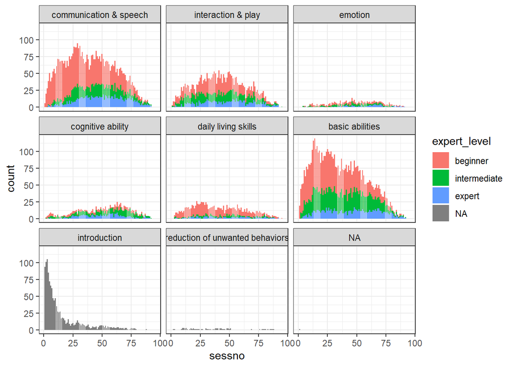

```r
ggplot(df_trial,aes(x=sessno,fill=expert_level))+geom_bar()+facet_wrap(~dev_area)
```

## 1.7 changes and stability of aims

- showing exemplary participants
- 3. Prüfung der weiteren Angaben der Therapieziel im Verlauf der Therapie -> Stabilität bzw. Wechsel in andere Kategorie.

```r
print('discussion points: which further variables to consider: Übung durchgeführt?, Einzelnes Ziel')
```

```
## [1] "discussion points: which further variables to consider: Übung durchgeführt?, Einzelnes Ziel"
```

```r
#split by participant
list_trial<-split(df_trial,interaction(df_trial$centno,df_trial$scrnno,drop=T))
list_trial<-lapply(list_trial,function(x){x[order(x$sessno),]})

#participant with low consistency
test<-list_trial[[10]]
test<-test[test$dev_area!='introduction',names(test) %in% c('sessno','aim','aims','expert_level')]
test$aims_level<-paste(test$aims,test$expert_level,test$achieve)
test<-reshape2::dcast(test, sessno ~ aim,value.var='aims_level')

 test %>%
      kbl(caption = 'aims of participant with low stability') %>%
      kable_classic(full_width = F, html_font = "Cambria")
```

aims of participant with low stability

| sessno | 1 | 2 | 3 | 4 | 5 | 6 | 7 |
| --- | --- | --- | --- | --- | --- | --- | --- |
| 13 | attention control intermediate | eye contact beginner | NA | NA | NA | NA | NA |
| 15 | attention control intermediate | eye contact beginner | NA | temporal orientation beginner | NA | NA | NA |
| 16 | NA | eye contact beginner | NA | temporal orientation beginner | NA | NA | NA |
| 18 | attention control intermediate | NA | expressive language extended intermediate | temporal orientation beginner | NA | NA | NA |
| 19 | attention control intermediate | eye contact beginner | expressive language extended intermediate | NA | NA | NA | NA |
| 20 | NA | NA | NA | NA | expressive language extended intermediate | temporal orientation beginner | NA |
| 21 | NA | NA | attention control intermediate | eye contact beginner | expressive language extended intermediate | temporal orientation beginner | emotion regulation beginner |
| 22 | NA | NA | NA | eye contact beginner | NA | NA | NA |
| 23 | NA | NA | NA | eye contact beginner | NA | temporal orientation beginner | NA |
| 24 | NA | attention control intermediate | NA | NA | expressive language extended intermediate | emotion regulation beginner | NA |
| 25 | NA | NA | attention control intermediate | NA | NA | NA | NA |
| 29 | NA | NA | eye contact beginner | temporal orientation beginner | NA | emotion regulation beginner | attention control intermediate |
| 30 | NA | NA | NA | NA | NA | NA | attention control intermediate |
| 31 | NA | NA | eye contact beginner | NA | NA | NA | NA |

```r
#participant with high consistency
test<-list_trial[[1]]
test<-test[!(test$dev_area %in% c('introduction','reduction of unwanted behaviors')),
           names(test) %in% c('sessno','aim','aims','expert_level')]
test$aims_level<-paste(test$aims,test$expert_level,test$achieve)
test<-reshape2::dcast(test, sessno ~ aim,value.var='aims_level')

 test %>%
      kbl(caption = 'aims of participant with high stability') %>%
      kable_classic(full_width = F, html_font = "Cambria")
```

aims of participant with high stability

| sessno | 1 | 2 | 3 | 4 | 5 | 6 | 7 | 8 |
| --- | --- | --- | --- | --- | --- | --- | --- | --- |
| 6 | NA | NA | NA | NA | NA | eye contact beginner | expressive language (supported) beginner | NA |
| 7 | NA | NA | attention control beginner | imitation beginner | imitation expert | eye contact beginner | NA | NA |
| 8 | NA | NA | NA | imitation beginner | NA | NA | eye contact intermediate | expressive language (supported) beginner |
| 9 | NA | NA | attention control beginner | imitation beginner | imitation expert | NA | eye contact intermediate | NA |
| 10 | NA | NA | attention control beginner | NA | imitation expert | NA | NA | expressive language (supported) beginner |
| 12 | NA | NA | attention control beginner | NA | NA | NA | NA | expressive language (supported) beginner |
| 13 | NA | NA | NA | imitation expert | NA | NA | expressive language (supported) beginner | NA |
| 14 | NA | attention control beginner | imitation beginner | NA | eye contact intermediate | NA | expressive language (supported) beginner | NA |
| 15 | attention control beginner | imitation beginner | imitation expert | eye contact beginner | NA | NA | NA | NA |
| 16 | attention control beginner | NA | NA | NA | NA | expressive language (supported) beginner | expressive language extended beginner | NA |
| 17 | NA | imitation beginner | imitation expert | eye contact beginner | eye contact intermediate | NA | expressive language extended beginner | NA |
| 18 | attention control beginner | imitation beginner | imitation expert | NA | eye contact intermediate | expressive language (supported) beginner | expressive language extended beginner | NA |
| 19 | attention control beginner | imitation beginner | imitation expert | eye contact beginner | eye contact intermediate | expressive language (supported) beginner | expressive language extended beginner | NA |
| 20 | NA | imitation beginner | NA | eye contact beginner | eye contact intermediate | expressive language (supported) beginner | expressive language extended beginner | NA |
| 22 | NA | NA | imitation expert | eye contact beginner | eye contact intermediate | expressive language (supported) beginner | NA | NA |
| 23 | attention control beginner | imitation beginner | imitation expert | eye contact beginner | eye contact intermediate | NA | expressive language extended beginner | NA |
| 24 | attention control beginner | imitation beginner | imitation expert | NA | NA | expressive language (supported) beginner | NA | NA |
| 25 | attention control beginner | imitation beginner | imitation expert | NA | NA | NA | NA | NA |
| 26 | NA | NA | imitation expert | NA | eye contact intermediate | expressive language (supported) beginner | expressive language extended beginner | NA |
| 27 | NA | imitation beginner | imitation expert | NA | eye contact intermediate | expressive language (supported) beginner | expressive language extended beginner | NA |
| 28 | NA | imitation beginner | imitation expert | eye contact beginner | eye contact intermediate | expressive language (supported) beginner | expressive language extended beginner | NA |
| 29 | attention control beginner | imitation beginner | NA | eye contact beginner | eye contact intermediate | expressive language (supported) beginner | NA | NA |
| 30 | NA | imitation beginner | imitation expert | eye contact beginner | eye contact intermediate | expressive language (supported) beginner | expressive language extended beginner | NA |
| 31 | attention control beginner | imitation beginner | eye contact beginner | NA | expressive language (supported) beginner | expressive language extended beginner | imitation expert | NA |
| 32 | attention control beginner | imitation beginner | imitation expert | NA | eye contact intermediate | expressive language (supported) beginner | expressive language extended beginner | NA |
| 33 | attention control beginner | NA | imitation expert | eye contact beginner | eye contact intermediate | expressive language (supported) beginner | NA | NA |
| 34 | attention control beginner | NA | NA | NA | NA | NA | NA | NA |
| 36 | NA | NA | NA | NA | NA | NA | expressive language extended beginner | NA |
| 37 | attention control beginner | NA | imitation expert | NA | NA | NA | expressive language extended beginner | NA |
| 38 | NA | imitation beginner | NA | NA | eye contact intermediate | expressive language (supported) beginner | expressive language extended beginner | NA |
| 39 | attention control beginner | imitation beginner | NA | eye contact beginner | eye contact intermediate | expressive language (supported) beginner | expressive language extended beginner | NA |
| 40 | NA | imitation beginner | imitation expert | eye contact beginner | NA | NA | expressive language extended beginner | NA |
| 41 | attention control beginner | imitation beginner | imitation expert | imitation intermediate | eye contact beginner | eye contact intermediate | NA | expressive language extended beginner |
| 42 | attention control beginner | imitation beginner | NA | imitation expert | eye contact beginner | eye contact intermediate | NA | NA |
| 44 | attention control beginner | imitation beginner | imitation intermediate | imitation expert | eye contact beginner | eye contact intermediate | expressive language (supported) beginner | NA |
| 45 | attention control beginner | imitation beginner | imitation intermediate | imitation expert | NA | NA | NA | expressive language extended beginner |
| 46 | attention control beginner | imitation beginner | imitation intermediate | NA | eye contact beginner | eye contact intermediate | expressive language (supported) beginner | expressive language extended beginner |
| 47 | NA | imitation beginner | imitation intermediate | imitation expert | eye contact intermediate | eye contact beginner | expressive language (supported) beginner | NA |
| 48 | attention control beginner | NA | imitation intermediate | imitation expert | eye contact intermediate | eye contact beginner | expressive language (supported) beginner | expressive language extended beginner |
| 49 | attention control beginner | NA | imitation intermediate | imitation expert | eye contact intermediate | eye contact beginner | expressive language (supported) beginner | expressive language extended beginner |
| 50 | NA | NA | NA | imitation expert | eye contact beginner | eye contact intermediate | expressive language (supported) beginner | expressive language extended beginner |
| 51 | attention control beginner | NA | imitation intermediate | imitation expert | eye contact intermediate | eye contact beginner | NA | expressive language extended beginner |
| 52 | attention control beginner | imitation beginner | imitation intermediate | imitation expert | eye contact beginner | eye contact intermediate | NA | expressive language extended beginner |
| 54 | NA | NA | NA | imitation expert | NA | eye contact intermediate | NA | expressive language extended beginner |
| 55 | attention control beginner | imitation beginner | NA | imitation expert | NA | eye contact intermediate | expressive language (supported) intermediate | expressive language extended beginner |
| 56 | NA | imitation beginner | NA | imitation expert | eye contact beginner | NA | expressive language (supported) intermediate | expressive language extended beginner |
| 57 | attention control beginner | imitation beginner | imitation intermediate | NA | eye contact beginner | NA | expressive language (supported) intermediate | expressive language extended beginner |
| 58 | attention control beginner | NA | imitation intermediate | NA | NA | eye contact intermediate | NA | expressive language extended beginner |
| 60 | attention control beginner | imitation beginner | NA | imitation expert | NA | eye contact intermediate | NA | expressive language extended beginner |
| 61 | NA | imitation beginner | imitation intermediate | imitation expert | NA | eye contact intermediate | NA | expressive language extended beginner |
| 65 | NA | NA | imitation intermediate | imitation expert | eye contact beginner | eye contact intermediate | NA | expressive language extended beginner |
| 66 | attention control beginner | imitation beginner | imitation expert | NA | NA | eye contact intermediate | expressive language (supported) intermediate | expressive language extended beginner |
| 68 | attention control beginner | NA | imitation intermediate | imitation expert | eye contact beginner | eye contact intermediate | expressive language (supported) intermediate | expressive language extended beginner |
| 69 | attention control beginner | NA | imitation intermediate | imitation expert | eye contact beginner | NA | expressive language (supported) intermediate | NA |

```r
# #aims by participant
# table_aimspart<-by(df_firstaims$aims,interaction(df_firstaims$centno,df_firstaims$scrnno,drop=T),function(x){table(droplevels(x))})
#
# table_aimspart<-sapply(table_aimspart,dimnames)
# max_length<-max(sapply(table_aimspart,length))
# table_aimspart<-lapply(table_aimspart,function(x){
#   current_length<-length(x)
#   new_vector<-rep(NA,max_length)
#   new_vector[1:current_length]<-x
#   return(new_vector)})
#
# table_aimspart<-rbind.data.frame(table_aimspart)
#
# table_aimspart<-data.frame(t(table_aimspart))
# names(table_aimspart)<-paste('goal',1:length(names(table_aimspart)))
# row.names(table_aimspart)<-substr(row.names(table_aimspart),2,nchar(row.names(table_aimspart)))
```